# MANJU GOYAL - Red Wine Quality

The red wine quality data is a dataset by Cortez et al in which different physiochemical wine properties that can be tested in lab are provided along with quality rating from wine experts. Since the price of wine varies so much, it makes one wonder if there are certain properties which can be associated with higher quality and better still, if we can make a model that can help predict quality of wine based on some properties. In this analysis, my focus will be on understanding the relation between the physiochemical properties and quality.

========================================================

# Univariate Plots Section

Let us first look at the structure of the dataset

```
## 'data.frame':    1599 obs. of  13 variables:
##  $ X                   : int  1 2 3 4 5 6 7 8 9 10 ...
##  $ fixed.acidity       : num  7.4 7.8 7.8 11.2 7.4 7.4 7.9 7.3 7.8 7.5 ...
##  $ volatile.acidity    : num  0.7 0.88 0.76 0.28 0.7 0.66 0.6 0.65 0.58 0.5 ...
##  $ citric.acid         : num  0 0 0.04 0.56 0 0 0.06 0 0.02 0.36 ...
##  $ residual.sugar      : num  1.9 2.6 2.3 1.9 1.9 1.8 1.6 1.2 2 6.1 ...
##  $ chlorides           : num  0.076 0.098 0.092 0.075 0.076 0.075 0.069 0.065 0.073 0.071 ...
##  $ free.sulfur.dioxide : num  11 25 15 17 11 13 15 15 9 17 ...
##  $ total.sulfur.dioxide: num  34 67 54 60 34 40 59 21 18 102 ...
##  $ density             : num  0.998 0.997 0.997 0.998 0.998 ...
##  $ pH                  : num  3.51 3.2 3.26 3.16 3.51 3.51 3.3 3.39 3.36 3.35 ...
##  $ sulphates           : num  0.56 0.68 0.65 0.58 0.56 0.56 0.46 0.47 0.57 0.8 ...
##  $ alcohol             : num  9.4 9.8 9.8 9.8 9.4 9.4 9.4 10 9.5 10.5 ...
##  $ quality             : int  5 5 5 6 5 5 5 7 7 5 ...
```

It turns out that the dataframe has 12 variables - fixed acidity, volatile acidity, citric acid, residual sugar, chlorides, sulphates, free and total sulphur dioxide, density, pH, sulphates, alcohol and quality. Most of our analysis will be focussed on seeing how the first 11 of these variables impact the quality of the red wine.

Next, let us look at the data summary to see the distribution of the data

```
##        X          fixed.acidity   volatile.acidity  citric.acid
##  Min.   :   1.0   Min.   : 4.60   Min.   :0.1200   Min.   :0.000
##  1st Qu.: 400.5   1st Qu.: 7.10   1st Qu.:0.3900   1st Qu.:0.090
##  Median : 800.0   Median : 7.90   Median :0.5200   Median :0.260
##  Mean   : 800.0   Mean   : 8.32   Mean   :0.5278   Mean   :0.271
##  3rd Qu.:1199.5   3rd Qu.: 9.20   3rd Qu.:0.6400   3rd Qu.:0.420
##  Max.   :1599.0   Max.   :15.90   Max.   :1.5800   Max.   :1.000
##  residual.sugar     chlorides       free.sulfur.dioxide
##  Min.   : 0.900   Min.   :0.01200   Min.   : 1.00
##  1st Qu.: 1.900   1st Qu.:0.07000   1st Qu.: 7.00
##  Median : 2.200   Median :0.07900   Median :14.00
##  Mean   : 2.539   Mean   :0.08747   Mean   :15.87
##  3rd Qu.: 2.600   3rd Qu.:0.09000   3rd Qu.:21.00
##  Max.   :15.500   Max.   :0.61100   Max.   :72.00
##  total.sulfur.dioxide    density             pH          sulphates
##  Min.   :  6.00       Min.   :0.9901   Min.   :2.740   Min.   :0.3300
##  1st Qu.: 22.00       1st Qu.:0.9956   1st Qu.:3.210   1st Qu.:0.5500
##  Median : 38.00       Median :0.9968   Median :3.310   Median :0.6200
##  Mean   : 46.47       Mean   :0.9967   Mean   :3.311   Mean   :0.6581
##  3rd Qu.: 62.00       3rd Qu.:0.9978   3rd Qu.:3.400   3rd Qu.:0.7300
##  Max.   :289.00       Max.   :1.0037   Max.   :4.010   Max.   :2.0000
##     alcohol         quality
##  Min.   : 8.40   Min.   :3.000
##  1st Qu.: 9.50   1st Qu.:5.000
##  Median :10.20   Median :6.000
##  Mean   :10.42   Mean   :5.636
##  3rd Qu.:11.10   3rd Qu.:6.000
##  Max.   :14.90   Max.   :8.000
```

Overall it seems, some variables such as free sulfur dioxide, total sulfur dioxide, sulphates, alcohol, fixed acdity are a little skewed or have outliers.

```
## [1] 3 8
```

Let us look at the most important variable of interest - quality first.

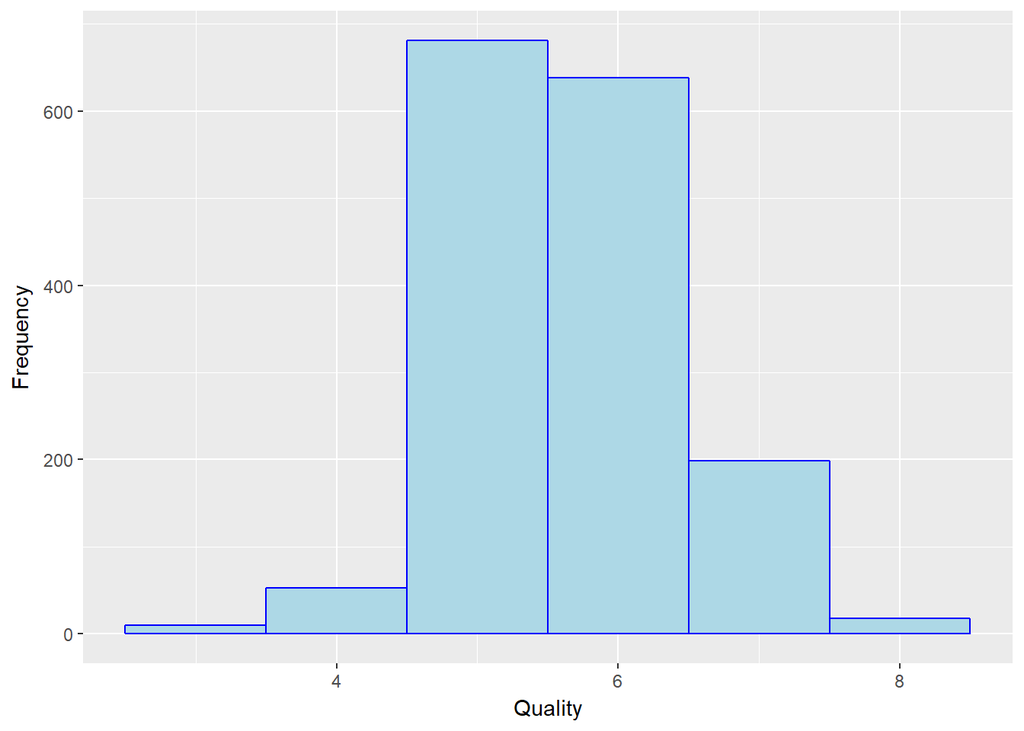

```r
qplot(x=quality, data=dat, xlab='Quality', ylab='Frequency',
      fill = I("lightblue"), col=I("blue"), binwidth=1)
```

It seems most wines are of medium quality and there are only a few wines that have low or high quality. Also since quality is a numeric variable, let us make another variable of quality thats categorical. For this, I intend to make 3 categories - low, medium and high quality.

```
## 'data.frame':    1599 obs. of  14 variables:
##  $ X                   : int  1 2 3 4 5 6 7 8 9 10 ...
##  $ fixed.acidity       : num  7.4 7.8 7.8 11.2 7.4 7.4 7.9 7.3 7.8 7.5 ...
##  $ volatile.acidity    : num  0.7 0.88 0.76 0.28 0.7 0.66 0.6 0.65 0.58 0.5 ...
##  $ citric.acid         : num  0 0 0.04 0.56 0 0 0.06 0 0.02 0.36 ...
##  $ residual.sugar      : num  1.9 2.6 2.3 1.9 1.9 1.8 1.6 1.2 2 6.1 ...
##  $ chlorides           : num  0.076 0.098 0.092 0.075 0.076 0.075 0.069 0.065 0.073 0.071 ...
##  $ free.sulfur.dioxide : num  11 25 15 17 11 13 15 15 9 17 ...
##  $ total.sulfur.dioxide: num  34 67 54 60 34 40 59 21 18 102 ...
##  $ density             : num  0.998 0.997 0.997 0.998 0.998 ...
##  $ pH                  : num  3.51 3.2 3.26 3.16 3.51 3.51 3.3 3.39 3.36 3.35 ...
##  $ sulphates           : num  0.56 0.68 0.65 0.58 0.56 0.56 0.46 0.47 0.57 0.8 ...
##  $ alcohol             : num  9.4 9.8 9.8 9.8 9.4 9.4 9.4 10 9.5 10.5 ...
##  $ quality             : int  5 5 5 6 5 5 5 7 7 5 ...
##  $ quality_cat         : chr  "Medium" "Medium" "Medium" "Medium" ...
```

Now, lets look at the distribution of this new variable to understand how it looks

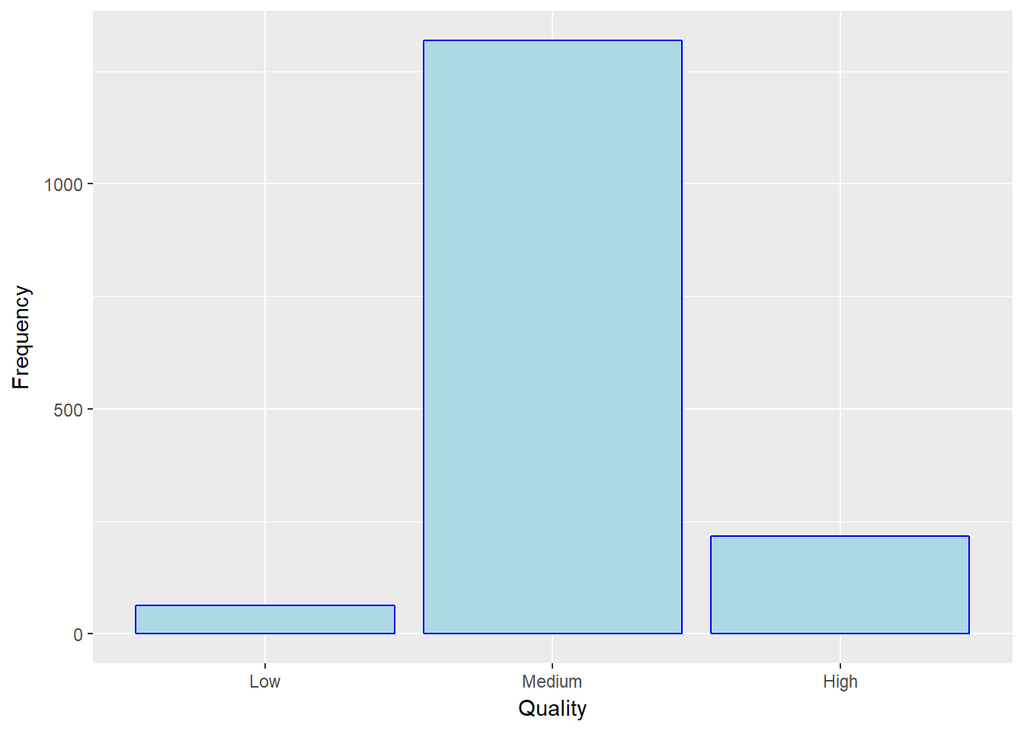

```r
# first let us order the categrical variable
dat$quality_cat <- factor(dat$quality_cat, c('Low','Medium','High'))
qplot(x=quality_cat, data=dat, xlab='Quality', ylab='Frequency',
      fill = I("lightblue"), col=I("blue"))
```

Clearly, we have much more data that is of medium quality wne as compared to that of low and high quality wine.

Next, let us look at histograms of all the other variables to understand their distribution as well. As I went about the analysis, I realised there were a lot of outliers that were skewing the data, so I tried to limit the data to have a better picture of how the distribution looks by setting xlim on the plots.

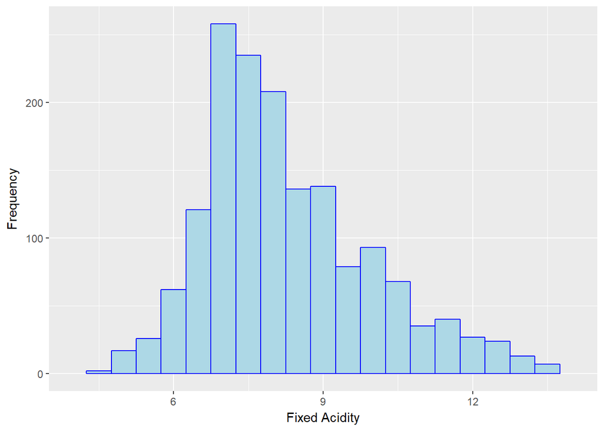

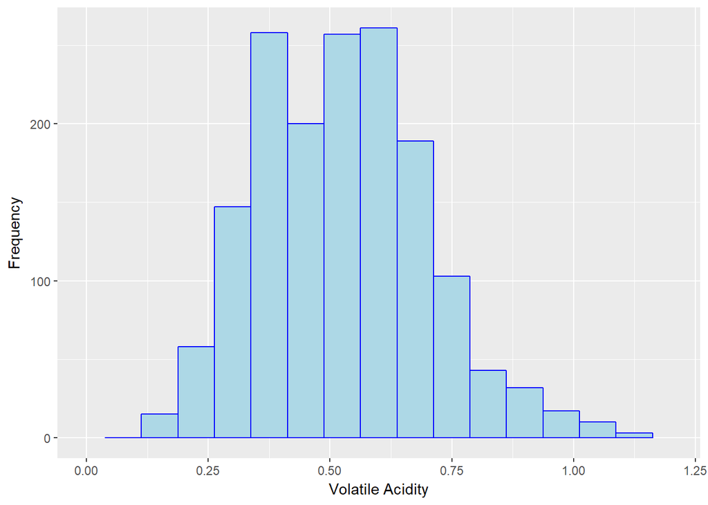

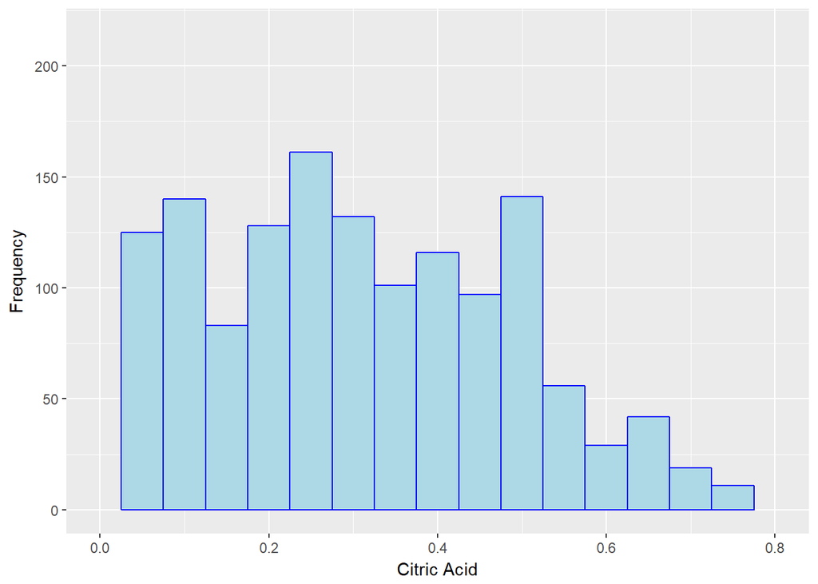

This is a very box like distribution.

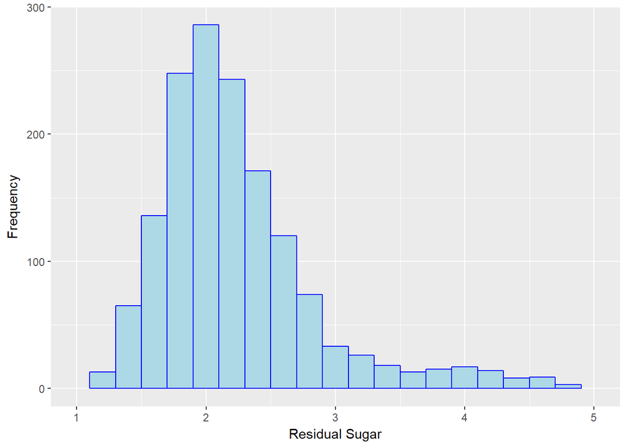

This distribution is also skewed to the right.

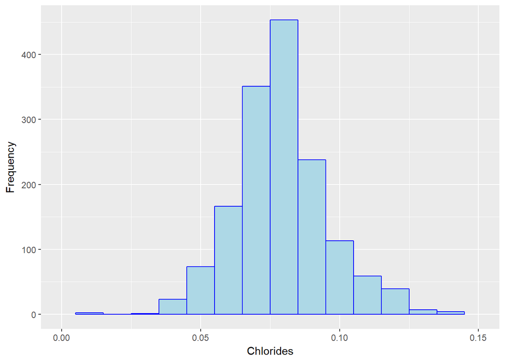

Chlorides are more normally distributed

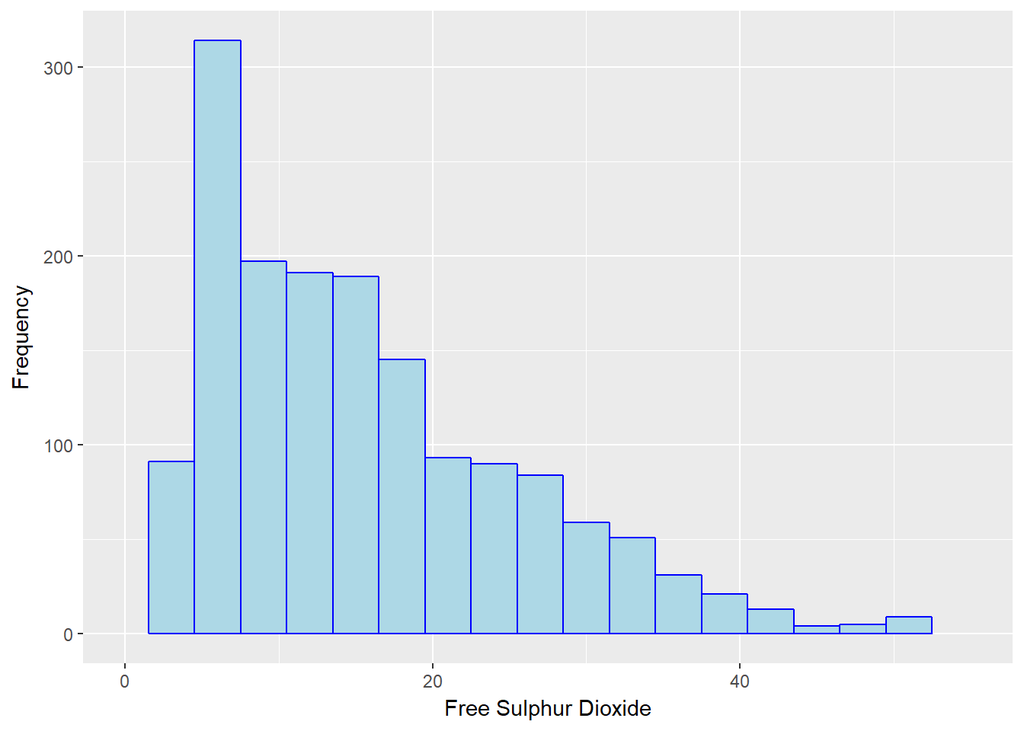

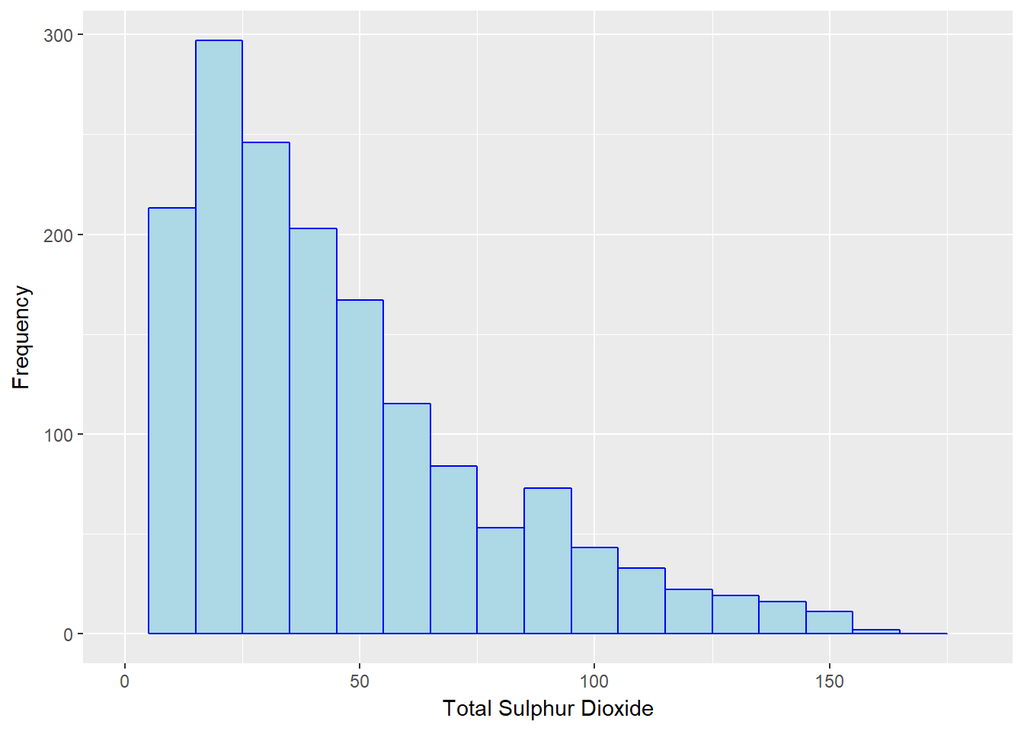

Both free and total sulphur dioxide are skewed to the right.

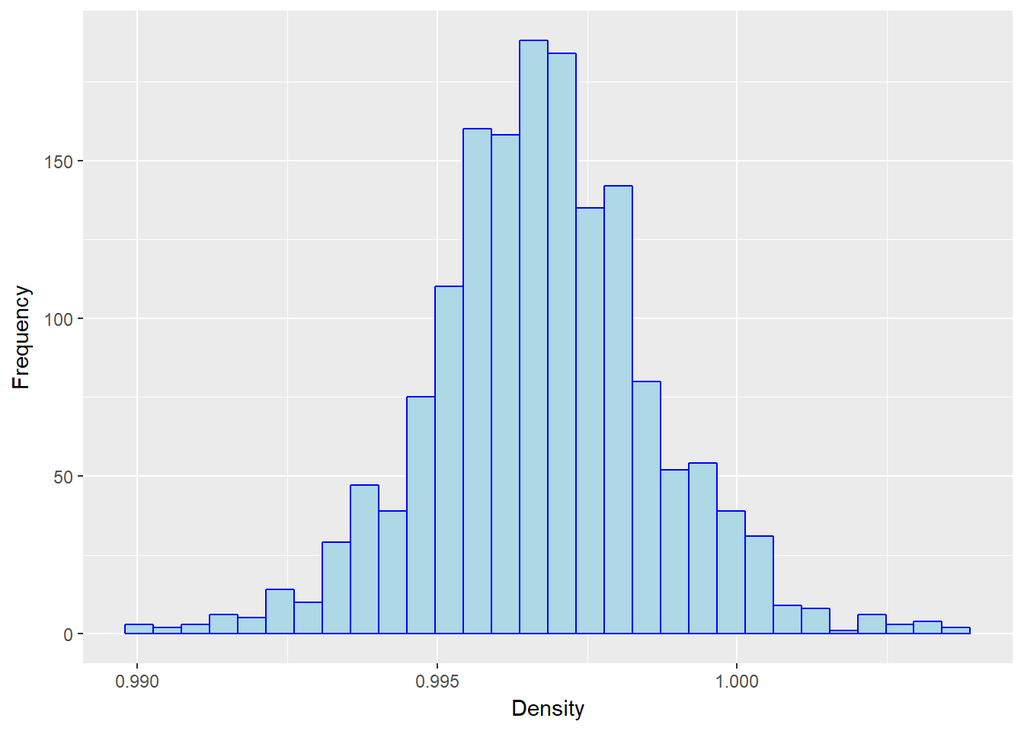

Interestingly density is more normally distributed,

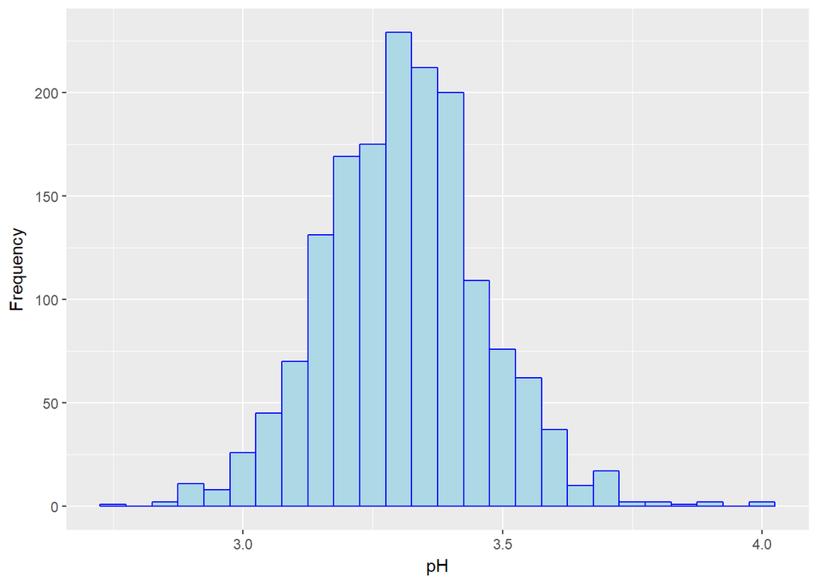

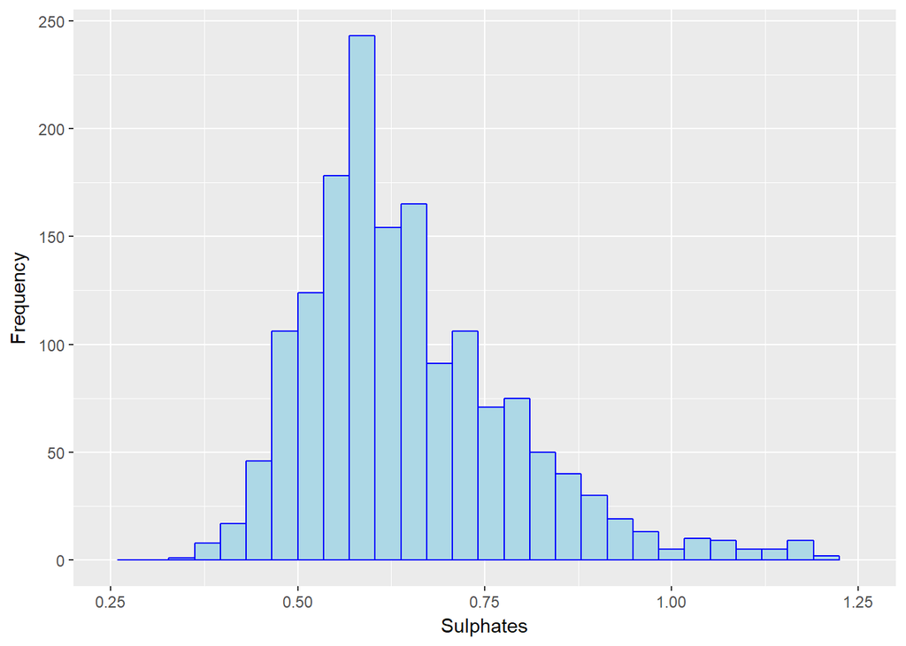

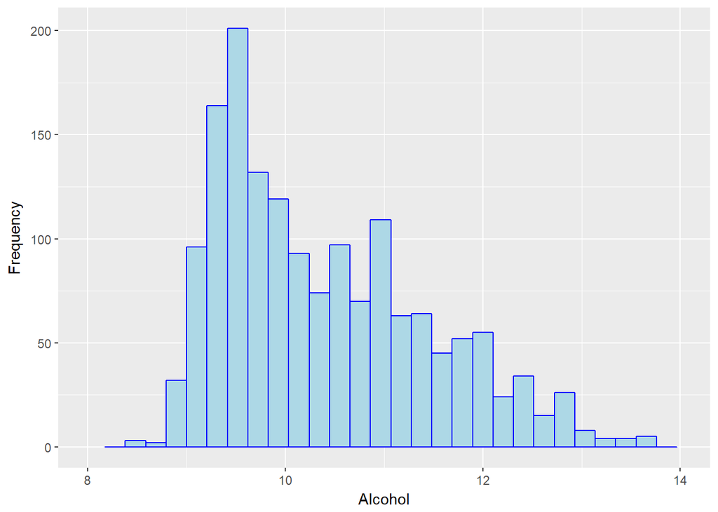

# Univariate Analysis

# Bivariate Plots Section

Let us look at the correlation matrix of the data and then plot using corrplot package

```
##                      fixed.acidity volatile.acidity citric.acid
## fixed.acidity                 1.00            -0.26        0.67
## volatile.acidity             -0.26             1.00       -0.55
## citric.acid                   0.67            -0.55        1.00
## residual.sugar                0.11             0.00        0.14
## chlorides                     0.09             0.06        0.20
## free.sulfur.dioxide          -0.15            -0.01       -0.06
## total.sulfur.dioxide         -0.11             0.08        0.04
## density                       0.67             0.02        0.36
## pH                           -0.68             0.23       -0.54
## sulphates                     0.18            -0.26        0.31
## alcohol                      -0.06            -0.20        0.11
## quality                       0.12            -0.39        0.23
##                      residual.sugar chlorides free.sulfur.dioxide
## fixed.acidity                  0.11      0.09               -0.15
## volatile.acidity               0.00      0.06               -0.01
## citric.acid                    0.14      0.20               -0.06
## residual.sugar                 1.00      0.06                0.19
## chlorides                      0.06      1.00                0.01
## free.sulfur.dioxide            0.19      0.01                1.00
## total.sulfur.dioxide           0.20      0.05                0.67
## density                        0.36      0.20               -0.02
## pH                            -0.09     -0.27                0.07
## sulphates                      0.01      0.37                0.05
## alcohol                        0.04     -0.22               -0.07
## quality                        0.01     -0.13               -0.05
##                      total.sulfur.dioxide density    pH sulphates alcohol
## fixed.acidity                       -0.11    0.67 -0.68      0.18   -0.06
## volatile.acidity                     0.08    0.02  0.23     -0.26   -0.20
## citric.acid                          0.04    0.36 -0.54      0.31    0.11
## residual.sugar                       0.20    0.36 -0.09      0.01    0.04
## chlorides                            0.05    0.20 -0.27      0.37   -0.22
## free.sulfur.dioxide                  0.67   -0.02  0.07      0.05   -0.07
## total.sulfur.dioxide                 1.00    0.07 -0.07      0.04   -0.21
## density                              0.07    1.00 -0.34      0.15   -0.50
## pH                                  -0.07   -0.34  1.00     -0.20    0.21
## sulphates                            0.04    0.15 -0.20      1.00    0.09
## alcohol                             -0.21   -0.50  0.21      0.09    1.00
## quality                             -0.19   -0.17 -0.06      0.25    0.48
##                      quality
## fixed.acidity           0.12
## volatile.acidity       -0.39
## citric.acid             0.23
## residual.sugar          0.01
## chlorides              -0.13
## free.sulfur.dioxide    -0.05
## total.sulfur.dioxide   -0.19
## density                -0.17
## pH                     -0.06
## sulphates               0.25
## alcohol                 0.48
## quality                 1.00
```

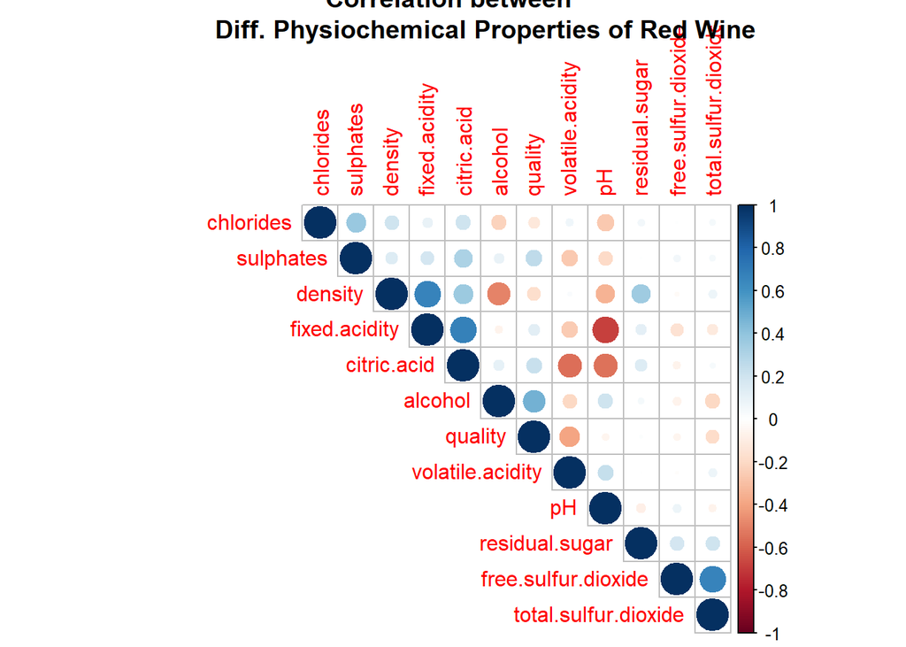

Reminder: correlation <0.3 means very weak or no correlation, correlation r between 0.3 and 0.5 is weak relation, correlation between 0.5 and 0.7 means moderate correlation and greater than 0.7 means a strong correlation.

Looking at the correlation plot is much easier to understand the plot than just reading the table. It helps us understand that there is a moderate negative correlation between pH and fixed acidity, pH and citric acid, volatile acidity and citric acid, alcohol and density . There is a moderate positive correlation between free and total sulphur dioxide, fixed acidity and citric acid, density and fixed acidity. weak positive correlation between chlorides and sulphates. The only variable that seems to have even a weak correlation with quality is alcohol(positive) and volatile acidity(negative).

Next, lets try to plot quality against alcohol and volatile acidity and also against some other variables that seem to be important from this test such as sulphates, pH, fixed acidity and citric acid.

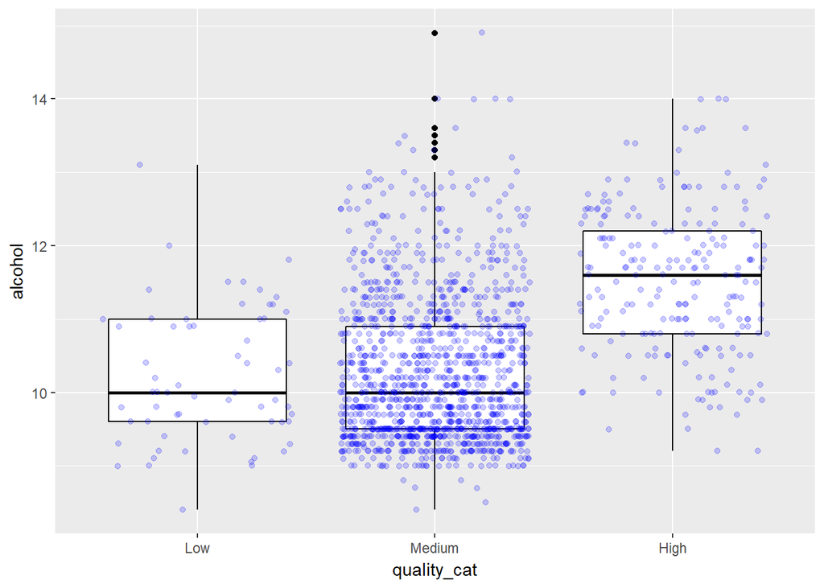

This is a much clear picture.Quality and alcohol content are slightly positively correlated. Next let’s look at quality and volatile acidity.

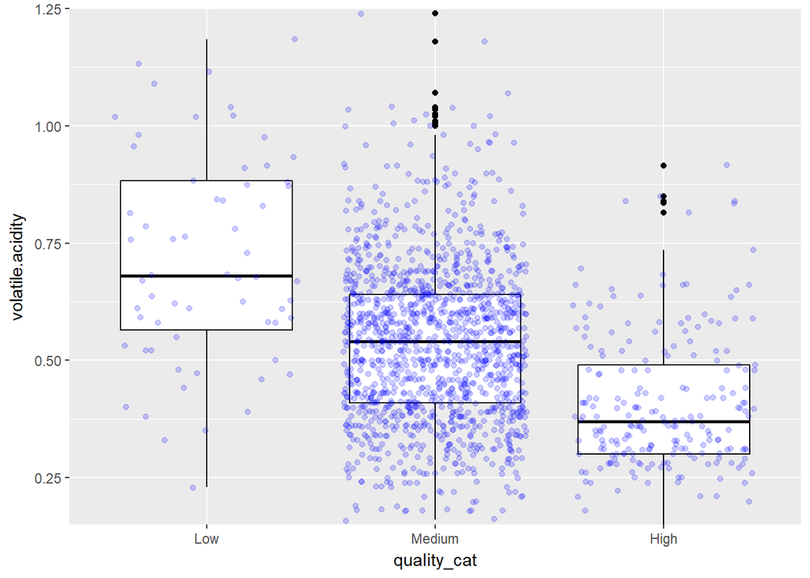

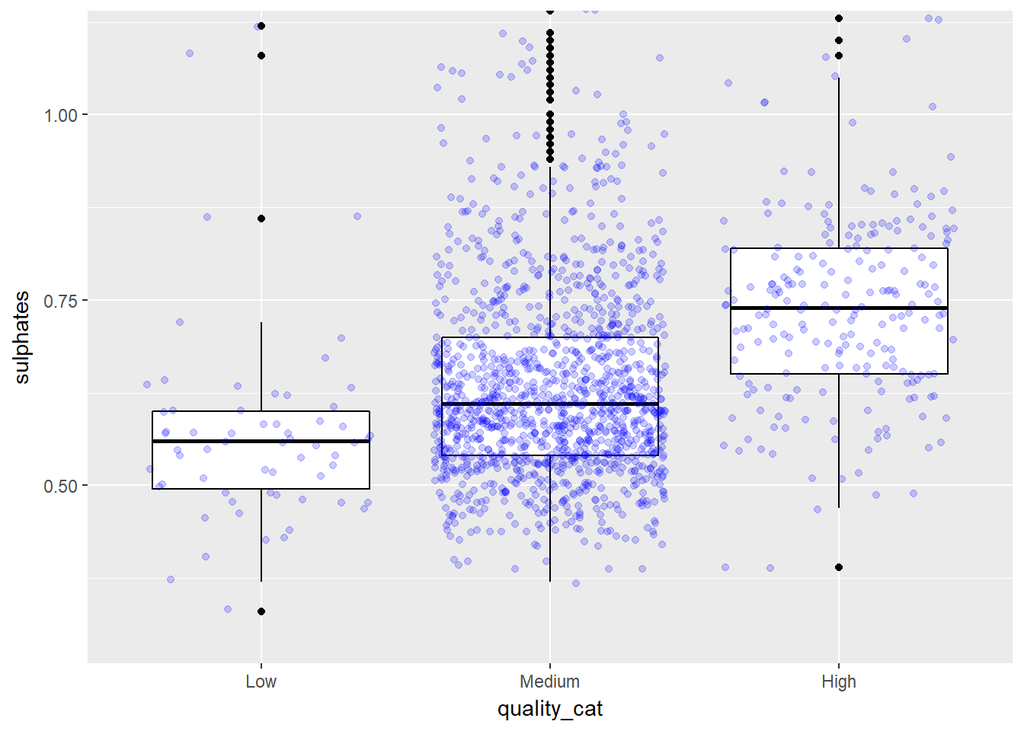

Sulphates seem to impact quality positively but then correlation coefficient was low. Also, the data is very less for low and high as compared to medium quality wines which might be skewing the results.

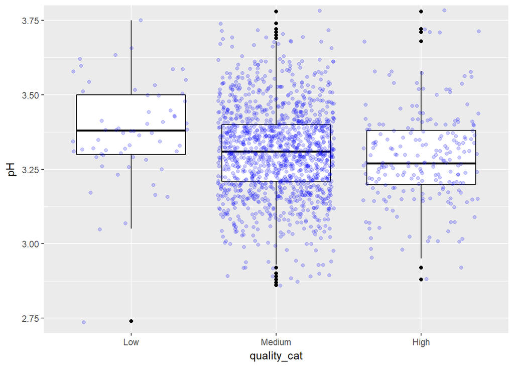

Here, the relation of pH with quality is not clear. It does not seem to have any specific or strong trend both from this graph and also from the correlation coefficient

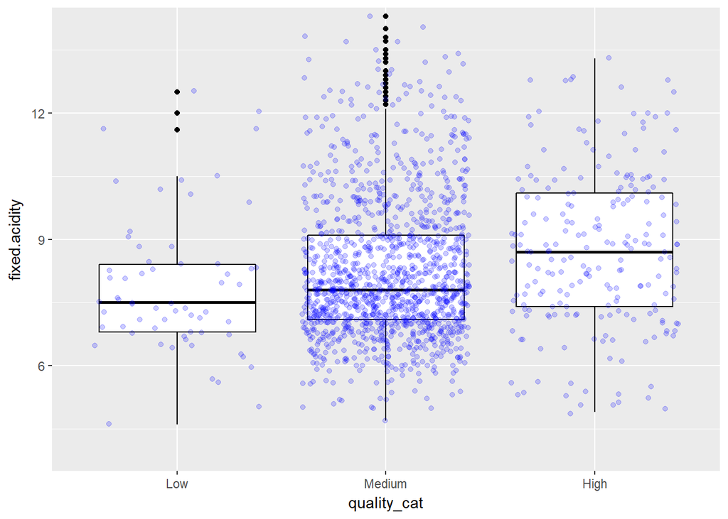

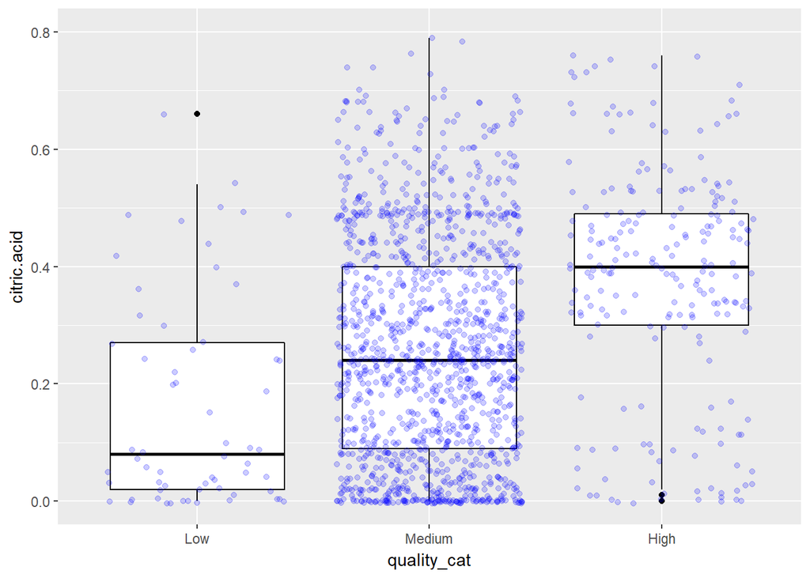

Citric acid seems to be positively correlated with quality if we look at just the median value but the entire dataset doesnt give the same picture.

So far, there seems to be some relationship between quality and volatile acidity(negative correlation), quality and alcohol content(positive correlation). Based on correlation values and this graph there definitely seems to be a relation between quality and citric acid, quality and sulphates though not a lot. Some plots do show some correlation when looked at just the median value but then the spread is so high and the correlation values are not big enough that they do suggest any strong correlations. Next, lets look at 2 or 3 factors together and their impact on quality if we can make out a trend.

The correlation values had suggested a moderate negative correlation between pH and fixed acidity, pH and citric acid, volatile acidity and citric acid, alcohol and density . There is a moderate positive correlation between fixed acidity and citric acid, fixed acidity and density, Weak positive correlation between chlorides and sulphates.

Since volatile acidity and alcohol were important factors for quality(as seen in above charts), any factor that impacts these will be interesting to see it with quality. I will be interested to see a plot of alcohol and density with quality as a parameter, another would be volatile acidity and citric acid with quality. I could also look at how any of these factors behave with sulphates as well. So, lets look at these bivariate relationships both individually and then with quality in multivariate section

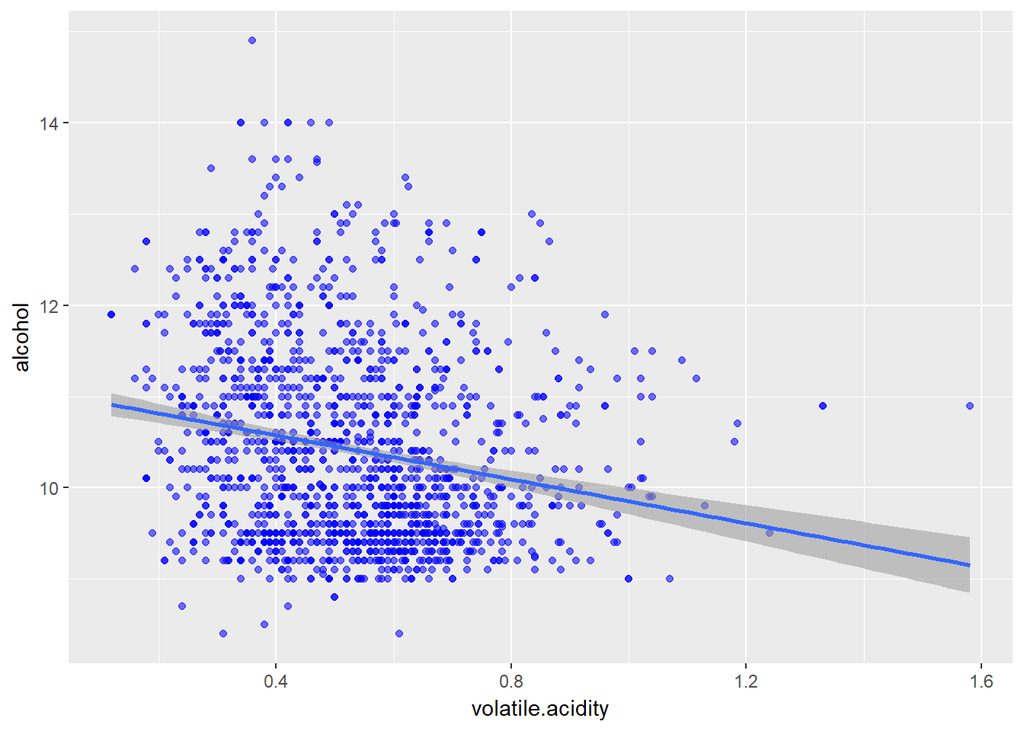

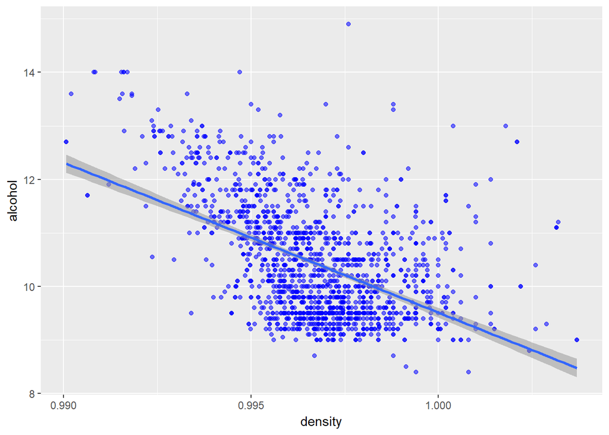

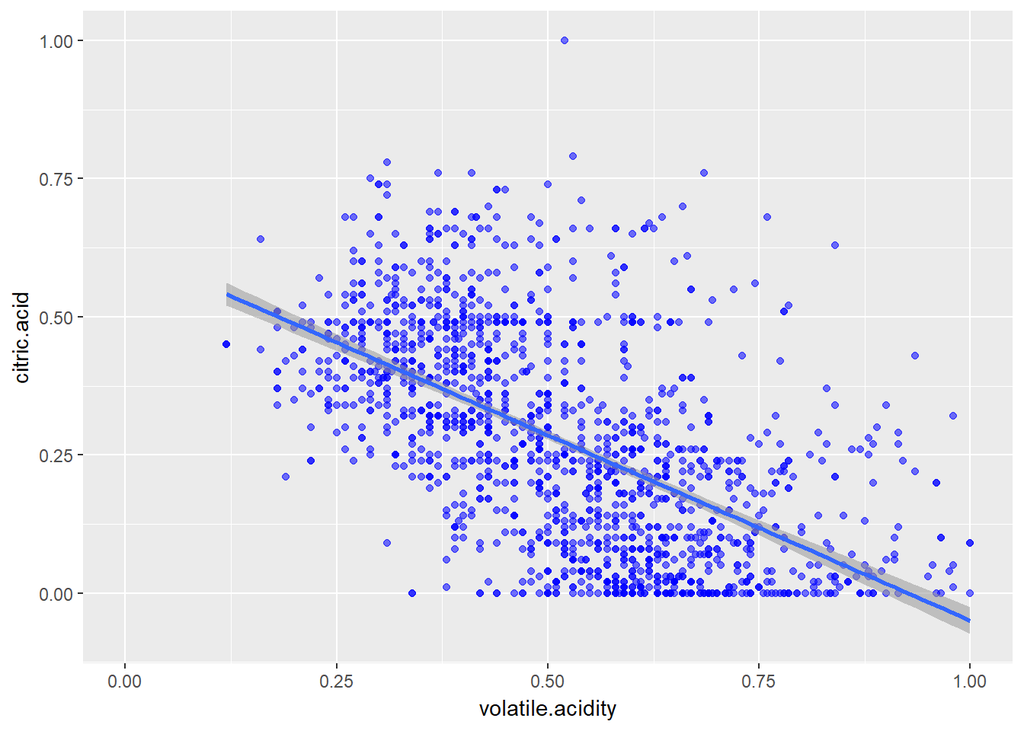

# Bivariate Analysis

# Multivariate Plots Section

This section will be an extension to the multivariate analysis and focus on some of the important factors we found there and their relation to quality

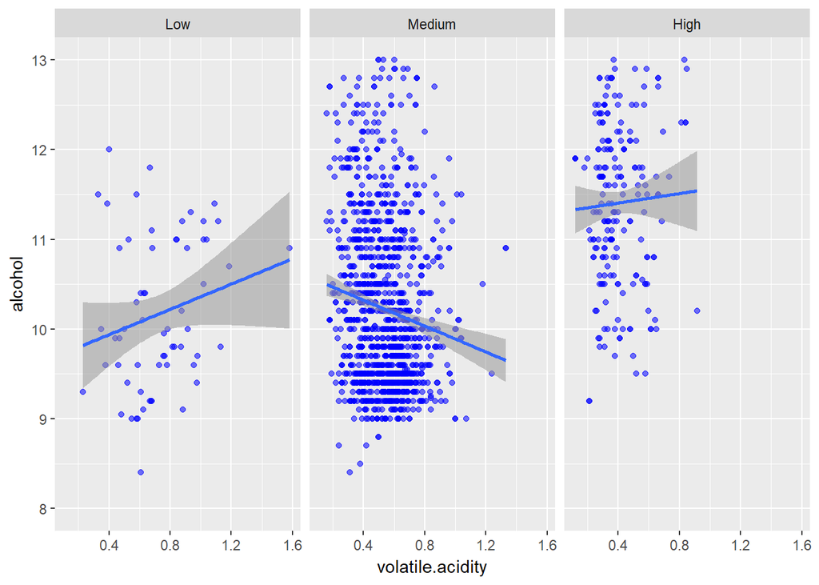

Though alcohol and volatile acidity are inversely related but when looked with quality as a factor, the relation is not the same for all kinds of quality. It seems for medium quality wines, alcohol is inversely relateded to volatile acidity but not for high and low quality wones indicating a non-linear overall relationship with quality perhaps. Given the low correlation coefficients of each of these factors, I have not made a regression model for this project. Now, let us look at the same relationship but at a different perspective

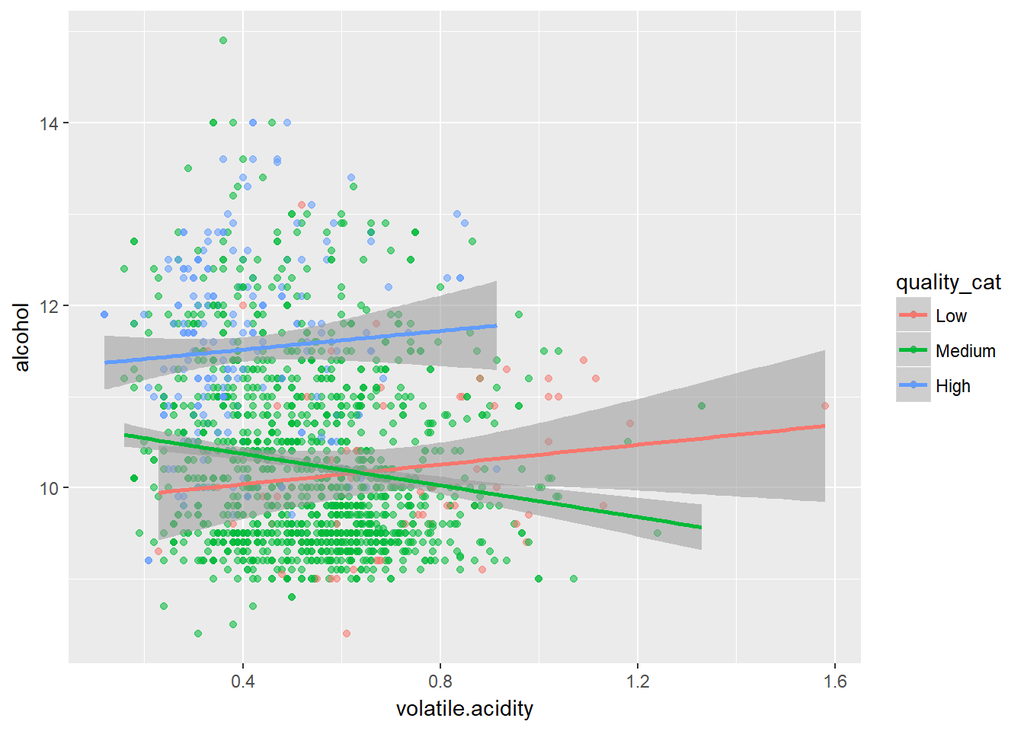

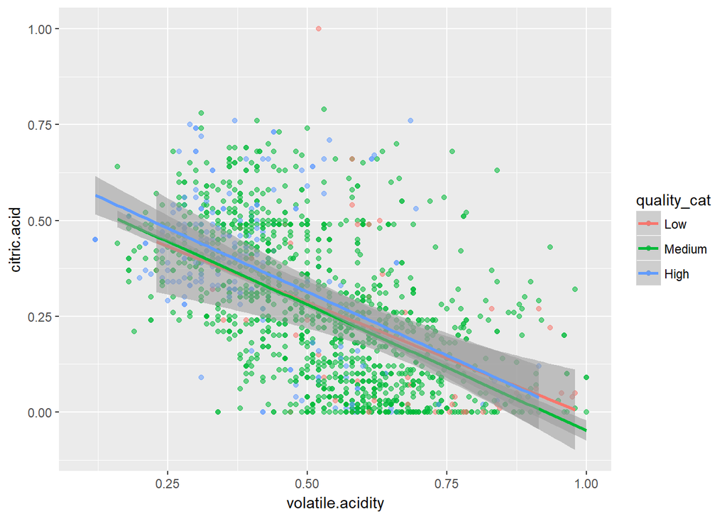

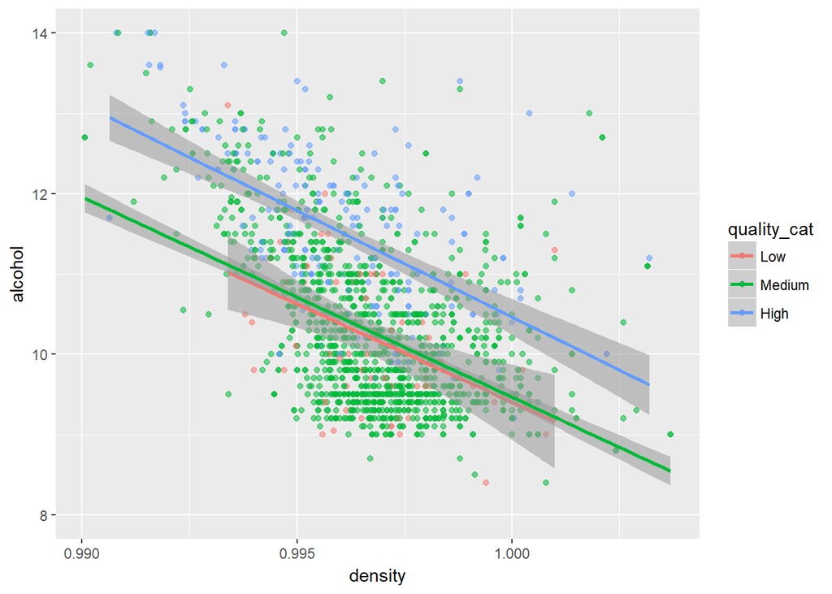

# Final Plots and Summary

### Plot One : Impact of Alcohol on Quality

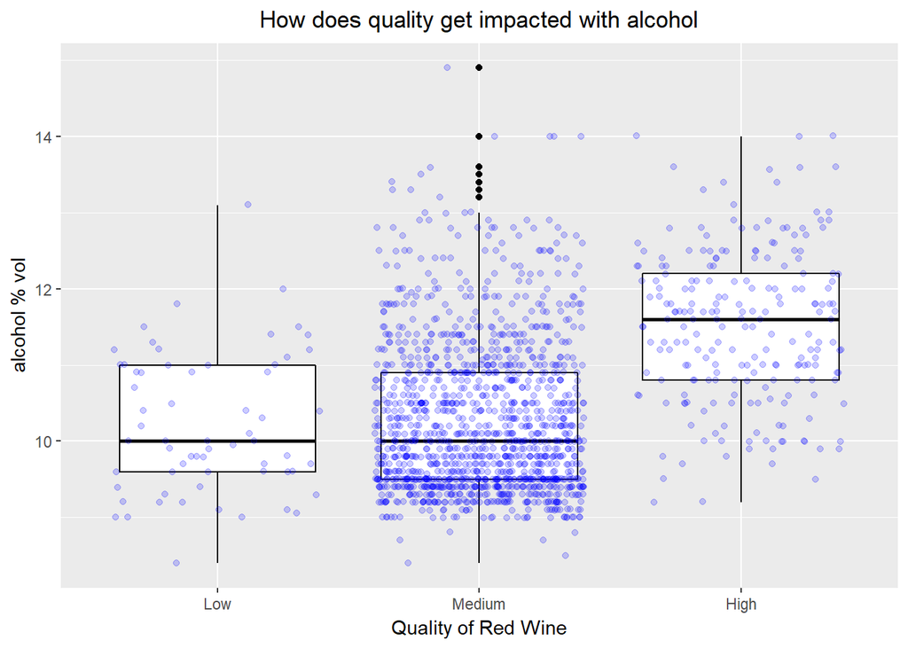

### Looking at the plot above, we know that alcohol is positively correlated with quality of wine, thought he relationship is not very strong. The values for medium quality wine are all over and we are just looking at the median when we talk about this positive corrleation. Thus, the relationship is not very strong.

### Plot Two: Impact of Volatile Acidity on quality

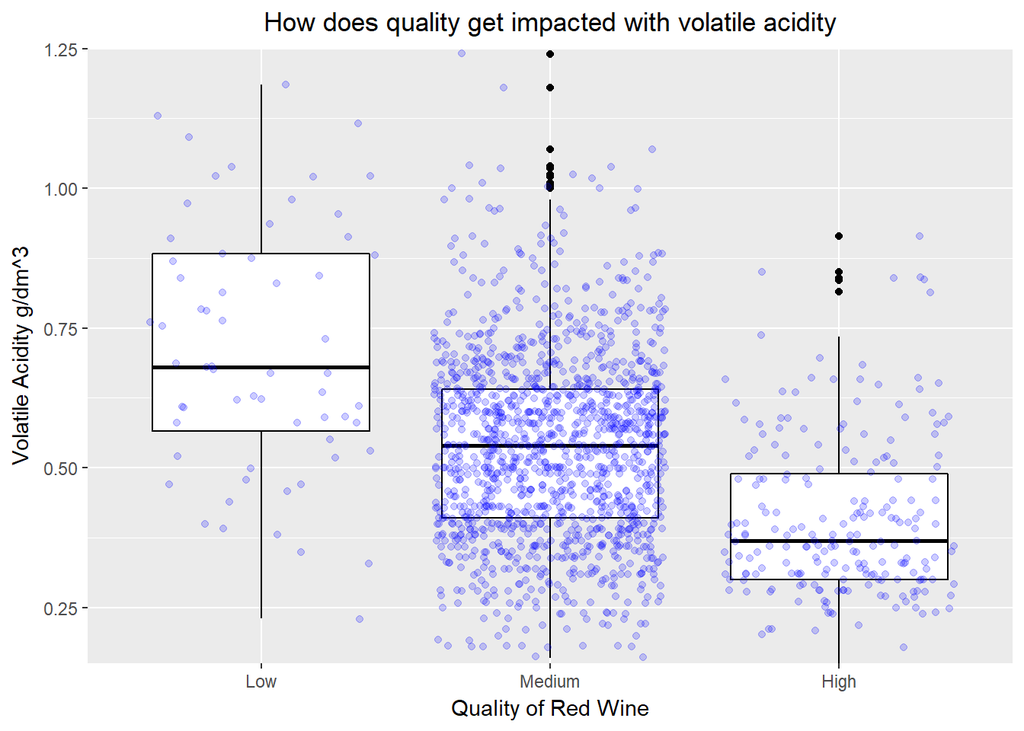

### This graph confirms the inverse relationship between quality and volatile acidity, even though not a strong one because the values of medium quality wines are spread all over and the relationship is more for medium or mean value rather than a very strong relationship. Next, let us look at how quality is related to volaile acidity and alcohol content together.

### Plot Three: Impact of both alcohol and volatile acidity on quality

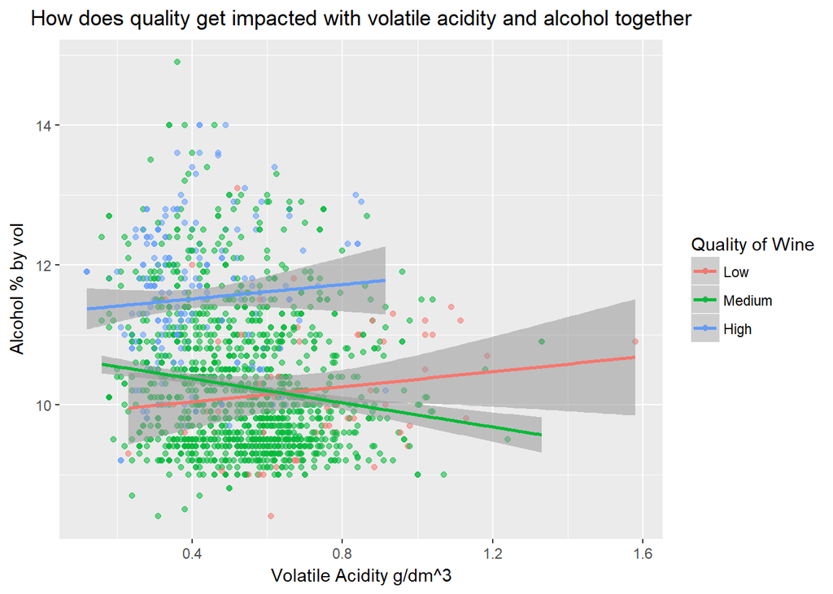

# Reflection

### 6. Future work on this dataset could include working on getting more data. Currently, dataset had more medium quality wines which might have hindered full analysis. We could also try understanding the quality rating more since as per the source of the dataset, this rating was obtained by sensory data of 3 wine experts. I believe wine is a very personal thing and giving it a score of 1 to 10 in itself makes very less sense since it will depend very much on your own tastes.